# Detection and visualization of cell-cell interactions using `LRBaseDbi`, `LRBase.XXX.eg.db`, and `scTensor` package

Koki Tsuyuzaki, Manabu Ishii and Itoshi Nikaido

Laboratory for Bioinformatics Research, RIKEN Center for Biosystems Dynamics Reseach

k.t.the-answer@hotmail.co.jp

1 September 2020

#### Package

scTensor 2.0.0

# 1 Introduction

## 1.1 About Cell-Cell Interaction (CCI)

Due to the rapid development of single-cell RNA-Seq (scRNA-Seq) technologies, wide variety of cell types such as multiple organs of a healthy person, stem cell niche and cancer stem cell have been found. Such complex systems are composed of communication between cells (cell-cell interaction or CCI).

Many CCI studies are based on the ligand-receptor (L-R)-pair list of FANTOM5 project[^1] as the evidence of CCI (http://fantom.gsc.riken.jp/5/suppl/Ramilowski_et_al_2015/data/PairsLigRec.txt). The project proposed the L-R-candidate genes by following two reasons.

1. **Subcellular Localization**
   1. Known Annotation (UniProtKB and HPRD) : The term **“Secreted”** for candidate ligand genes and **“Plasma Membrane”** for candidate receptor genes
   2. Computational Prediction (LocTree3 and PolyPhobius)
2. **Physical Binding of Proteins** : Experimentally validated PPI (protein-protein interaction) information of HPRD and STRING

The project also merged the data with previous L-R database such as IUPHAR/DLRP/HPMR and filter out the list without PMIDs.

Here, we extend a similar approach to the construction of the L-R-pair lists of 12 organisms and implemented as multiple R/*Bioconductor* annotation packages for sustainable maintenance (*LRBaseDbi* and LRBase.XXX.eg.db-type packages (Figure 1). XXX is the abbreviation of the scientific name of organisms such as *LRBase.Hsa.eg.db* for L-R database of Homo sapiens. Besides, we also developed *scTensor*, which is a method to detect CCI and the CCI-related L-R pairs simultaneously. This document provides the way to use *LRBaseDbi*, LRBase.XXX.eg.db-type packages, and *scTensor* package.

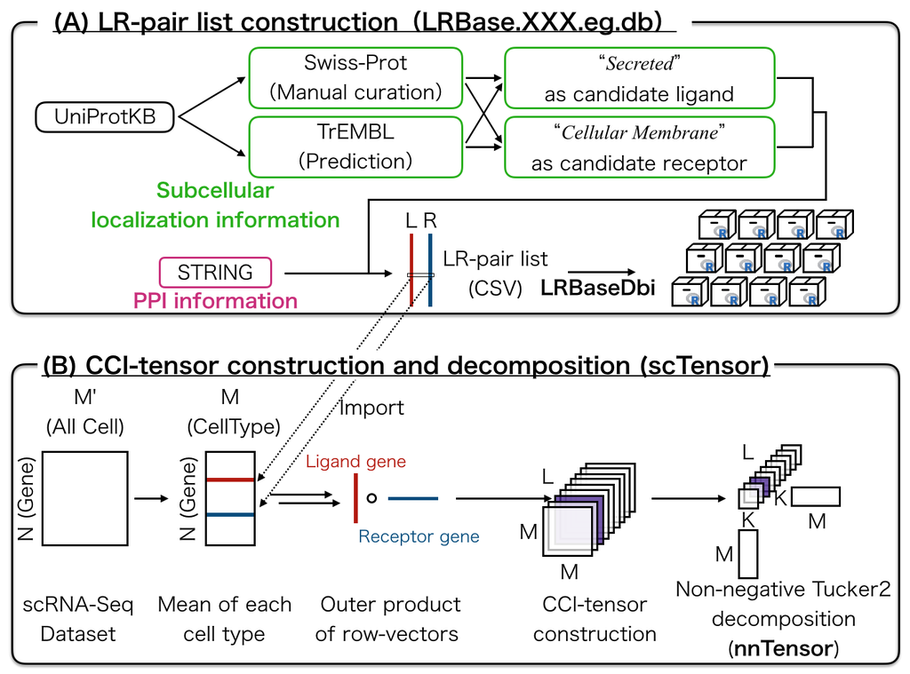

Figure 1 : Workflow of L-R-related packages

## 1.2 Dependencies of CCI-related Packages

Our framework is composed of some annotation packages and software packages (Figure 1).

*LRBaseDbi* package defines the class “LRBaseDb” for LRBase.XXX.eg.db-type packages such as *LRBase.Hsa.eg.db* and unify the object’s behavior such as column function. *nnTensor* which is a CRAN package, performs non-negative tensor decomposition, and *scTensor* internally imports the nnTensor. *scTensor* constructs CCI-tensor from a LRBase.XXX.eg.db package and scRNA-Seq dataset, decomposes to core tensor and factor matrices, and outputs HTML reports. See the next usage section for the details.

# 2 Usage

## 2.1 LRBase.XXX.eg.db (ligand-receptor database of 12 organisms)

To create the L-R-list of 12 organisms, we used the information about the subcellular localization of proteins from SWISSPROT (knowledge database) and TREMBL (computational prediction). We also used the PPI information from the STRING database (Figure 1). The proteins which are assigned to the term **“Secreted”** and **“Cellular Membrane”** are retrieved as candidate ligand and receptor, respectively. Finally, the L-R-pairs which is registered in STRING is extracted as candidate L-R-lists.

Following 12 organisms are implemented as LRBase.XXX.eg.db-type packages.

Table 1: The summary of 12 organisms of LRBase$_\cdot$XXX$_\cdot$eg$_\cdot$db packages.

| Organisms | Package Name | # Swiss-Prot (Secreted / Membrane) | # TrEMBL (Secreted / Membrane) | # STRING (PPI) | # Pair (Swiss-Prot ?? STRING) | # Pair (TrEMBL ?? STRING) |  |
| --- | --- | --- | --- | --- | --- | --- | --- |
| $\textit{Homo sapiens}$ | LRBase.Hsa.eg.db | 1592 / 2269 | 176 / 334 | 18838 | 21882 | 472 |  |
| $\textit{Mus musculus}$ | LRBase.Mmu.eg.db | 1309 / 1806 | 325 / 1555 | 19715 | 16386 | 476 |  |
| $\textit{Arabidopsis thaliana}$ | LRBase.Ath.eg.db | 1260 / 1001 | 244 / 80 | 24174 | 8697 | 94 |  |
| $\textit{Rattus norvegicus}$ | LRBase.Rno.eg.db | 643 / 983 | 232 / 1229 | 19963 | 5270 | 65 |  |
| $\textit{Bos taurus}$ | LRBase.Bta.eg.db | 517 / 448 | 192 / 390 | 18349 | 2220 | 237 |  |
| $\textit{Caenorhabditis elegans}$ | LRBase.Cel.eg.db | 198 / 247 | 28 / 60 | 13545 | 106 | 1 |  |
| $\textit{Drosophila melanogaster}$ | LRBase.Dme.eg.db | 249 / 333 | 89 / 148 | 11903 | 384 | 9 |  |
| $\textit{Danio rerio}$ | LRBase.Dre.eg.db | 119 / 169 | 318 / 376 | 21746 | 99 | 432 |  |
| $\textit{Gallus gallus}$ | LRBase.Gga.eg.db | 175 / 173 | 185 / 154 | 13084 | 140 | 105 |  |
| $\textit{Pongo abelii}$ | LRBase.Pab.eg.db | 80 / 134 | 212 / 211 | 16691 | 34 | 184 |  |
| $\textit{Xenopus Silurana tropicalis}$ | LRBase.Xtr.eg.db | 57 / 83 | 141 / 114 | 15338 | 19 | 107 |  |
| $\textit{Sus scrofa}$ | LRBase.Ssc.eg.db | 223 / 153 | 202 / 445 | 18683 | 277 | 130 |  |

### 2.1.1 columns, keytypes, keys, and select

Some data access functions are available for LRBase.XXX.eg.db-type packages. Any data table are retrieved by 4 functions defined by *AnnotationDbi*; `columns`, `keytypes`, `keys`, and `select` and commonly implemented by *LRBaseDbi* package. `columns` returns the rows which we can retrieve in LRBase.XXX.eg.db-type packages. `keytypes` returns the rows which can be used as the optional parameter in `keys` and select functions against LRBase.XXX.eg.db-type packages. `keys` function returns the value of keytype. `select` function returns the rows in particular columns, which are having user-specified keys. This function returns the result as a dataframe. See the vignette of *AnnotationDbi* for more details.

```r
columns(LRBase.Hsa.eg.db)
```

```
## [1] "GENEID_L" "GENEID_R" "SOURCEDB" "SOURCEID"
```

```r
keytypes(LRBase.Hsa.eg.db)
```

```
## [1] "GENEID_L" "GENEID_R" "SOURCEDB" "SOURCEID"
```

```r
key_HSA <- keys(LRBase.Hsa.eg.db, keytype="GENEID_L")
head(select(LRBase.Hsa.eg.db, keys=key_HSA[1:2],
            columns=c("GENEID_L", "GENEID_R"), keytype="GENEID_L"))
```

```
##   GENEID_L GENEID_R
## 1     4016       14
## 2   344752       14
## 3     4016     2678
## 4     4016     5251
## 5   344752    56670
```

### 2.1.2 Other functions

Other additional functions like `species`, `nomenclature`, and `listDatabases` are available. In each LRBase.XXX.eg.db-type package, `species` function returns the common name and `nomenclature` returns the scientific name. `listDatabases` function returns the source of data. `dbInfo` returns the information of the package. `dbfile` returns the directory where sqlite file is stored. `dbschema` returns the schema of the database. `dbconn` returns the connection to the sqlite database.

```r
lrPackageName(LRBase.Hsa.eg.db)
```

```
## [1] "LRBase.Hsa.eg.db"
```

```r
lrNomenclature(LRBase.Hsa.eg.db)
```

```
## [1] "Homo sapiens"
```

```r
species(LRBase.Hsa.eg.db)
```

```
## [1] "Human"
```

```r
lrListDatabases(LRBase.Hsa.eg.db)
```

```
##           SOURCEDB
## 1 SWISSPROT_STRING
## 2    TREMBL_STRING
## 3         SOURCEDB
## 4           IUPHAR
## 5             DLRP
```

```r
lrVersion(LRBase.Hsa.eg.db)
```

```
##        NAME VALUE
## 1 LRVERSION  2019
```

```r
dbInfo(LRBase.Hsa.eg.db)
```

```
##               NAME                                              VALUE
## 1       SOURCEDATE                                         7-Oct-2019
## 2      SOURCENAME1                                          SWISSPROT
## 3      SOURCENAME2                                             TREMBL
## 4      SOURCENAME3                                             STRING
## 5       SOURCEURL1 http://www.uniprot.org/uniprot/?query=reviewed:yes
## 6       SOURCEURL2  http://www.uniprot.org/uniprot/?query=reviewed:no
## 7       SOURCEURL3              https://string-db.org/cgi/download.pl
## 8         DBSCHEMA                                   LRBase.Hsa.eg.db
## 9  DBSCHEMAVERSION                                              1.2.0
## 10        ORGANISM                                       Homo sapiens
## 11         SPECIES                                              Human
## 12         package                                      AnnotationDbi
## 13         Db type                                           LRBaseDb
## 14       LRVERSION                                               2019
```

```r
dbfile(LRBase.Hsa.eg.db)
```

```
## [1] "/home/koki/Software/R-3.6.0/library/LRBase.Hsa.eg.db/extdata/LRBase.Hsa.eg.db.sqlite"
```

```r
dbschema(LRBase.Hsa.eg.db)
```

```
## [1] "CREATE TABLE `METADATA` (\n  `NAME` TEXT,\n  `VALUE` TEXT\n)"
## [2] "CREATE TABLE `DATA` (\n  `GENEID_L` TEXT,\n  `GENEID_R` TEXT,\n  `SOURCEID` TEXT,\n  `SOURCEDB` TEXT\n)"
```

```r
dbconn(LRBase.Hsa.eg.db)
```

```
## <SQLiteConnection>
##   Path: /home/koki/Software/R-3.6.0/library/LRBase.Hsa.eg.db/extdata/LRBase.Hsa.eg.db.sqlite
##   Extensions: TRUE
```

Combined with `dbGetQuery` function of *RSQLite* package, more complicated queries also can be submitted.

```r
suppressPackageStartupMessages(library("RSQLite"))
dbGetQuery(dbconn(LRBase.Hsa.eg.db),
  "SELECT * FROM DATA WHERE GENEID_L = '9068' AND GENEID_R = '14' LIMIT 10")
```

```
## [1] GENEID_L GENEID_R SOURCEID SOURCEDB
## <0 rows> (or 0-length row.names)
```

## 2.2 LRBaseDbi (Class definition and meta-packaging)

*LRBaseDbi* regulates the class definition of LRBaseDb object instantiated from `LRBaseDb`-class. Besides, *LRBaseDbi* the package generates user’s original LRBase.XXX.eg.db-type packages by `makeLRBasePackage` function. This function is inspired by our previous package *MeSHDbi*, which constructs user’s original MeSH.XXX.eg.db-type packages. Here we call this function “meta”-packaging. The 12 LRBase.XXX.eg.db-type packages described above are also generated by this “meta”-packaging. In this case, the only user have to specify are 1. an L-R-list containing the columns “GENEID_L” (ligand NCBI Gene IDs) and “GENEID_R” (receptor NCBI Gene IDs) and 2. a meta information table describing the L-R-list. `makeLRBasePackage` function generates LRBase.XXX.eg.db like below. **The gene identifier is limited as NCBI Gene ID for now.**

```r
example("makeLRBasePackage")
```

```
##
## mkLRBP> if(interactive()){
## mkLRBP+     ## makeLRBasePackage enable users to construct
## mkLRBP+     ## user's own custom LRBase package
## mkLRBP+     data(FANTOM5)
## mkLRBP+     head(FANTOM5)
## mkLRBP+
## mkLRBP+     # We are also needed to prepare meta data as follows.
## mkLRBP+     data(metaFANTOM5)
## mkLRBP+     metaFANTOM5
## mkLRBP+
## mkLRBP+     ## sets up a temporary directory for this example
## mkLRBP+     ## (users won't need to do this step)
## mkLRBP+     tmp <- tempfile()
## mkLRBP+     dir.create(tmp)
## mkLRBP+
## mkLRBP+     ## makes an Organism package for human called Homo.sapiens
## mkLRBP+     makeLRBasePackage(pkgname = "FANTOM5.Hsa.eg.db",
## mkLRBP+         data = FANTOM5,
## mkLRBP+         metadata = metaFANTOM5,
## mkLRBP+         organism = "Homo sapiens",
## mkLRBP+         version = "0.99.0",
## mkLRBP+         maintainer = "Koki Tsuyuzaki <k.t.the-answer@hotmail.co.jp>",
## mkLRBP+         author = "Koki Tsuyuzaki",
## mkLRBP+         destDir = tmp,
## mkLRBP+         license="Artistic-2.0")
## mkLRBP+ }
## Creating package in /tmp/RtmpFk9gxb/file2f0426a3e97b/FANTOM5.Hsa.eg.db
```

Although any package name is acceptable, note that if the organism that user summarized L-R-list is also described above (Table 1), same XXX-character is recommended. This is because of the HTML report function described later identifies the XXX-character and if the XXX is corresponding to the 12 organisms, the gene annotation of the generated HTML report will become rich.

## 2.3 scTensor (CCI-tensor construction, decomposition, and HTML reporting)

Combined with LRBase.XXX.eg.db-type package and user’s gene expression matrix of scRNA-Seq, *scTensor* detects CCIs and generates HTML reports for exploratory data inspection. The algorithm of *scTensor* is as follows.

Firstly, *scTensor* calculates the celltype-level mean vectors, searches the corresponding pair of genes in the row names of the matrix, and extracted as tow vectors.

Finally, the result of NTD2 is summarized as an HTML report. Because most of the plots are visualized by *plotly* package, the precise information of the plot can be interactively confirmed by user’s on-site web browser. The two factor matrices can be interactively viewed and which cell types and which L-R-pairs are likely to be interacted each other. The mode-3 (LR-pair direction) sum of the core tensor is calculated and visualized as Ligand-Receptor Patterns. Detail of (Ligand-Cell, Receptor-Cell, L-R-pair) Patterns are also visualized.

### 2.3.1 Creating a `SingleCellExperiment` object

Here, we use the scRNA-Seq dataset of male germline cells and somatic cells$^{3}$ GSE86146 as demo data. For saving the package size, the number of genes is strictly reduced by the standard of highly variable genes with a threshold of the p-value are 1E-150 (cf. [Identifying highly variable genes](http://pklab.med.harvard.edu/scw2014/subpop_tutorial.html)). That’s why we won’t argue about the scientific discussion of the data here.

We assume that user has a scRNA-Seq data matrix containing expression count data summarised at the level of the gene. First, we create a *SingleCellExperiment* object containing the data. The rows of the object correspond to features, and the columns correspond to cells. The gene identifier is limited as NCBI Gene ID for now.

To improve the interpretability of the following HTML report, we highly recommend that user specifies the two-dimensional data of input data (e.g. PCA, t-SNE, or UMAP). Such information is easily specified by `reducedDims` function of *SingleCellExperiment* package and is saved to reducedDims slot of `SingleCellExperiment` object (Figure 1).

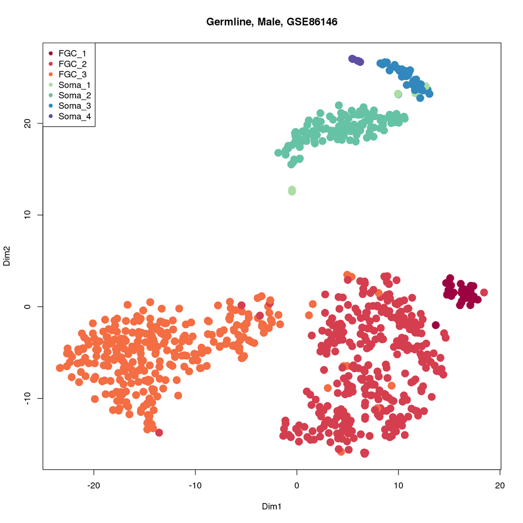

Figure 1: Germline, Male, GSE86146

```r
data(GermMale)
data(labelGermMale)
data(tsneGermMale)

sce <- SingleCellExperiment(assays=list(counts = GermMale))
reducedDims(sce) <- SimpleList(TSNE=tsneGermMale$Y)
plot(reducedDims(sce)[[1]], col=labelGermMale, pch=16, cex=2,
  xlab="Dim1", ylab="Dim2", main="Germline, Male, GSE86146")
legend("topleft", legend=c(paste0("FGC_", 1:3), paste0("Soma_", 1:4)),
  col=c("#9E0142", "#D53E4F", "#F46D43", "#ABDDA4", "#66C2A5", "#3288BD", "#5E4FA2"),
  pch=16)
```

Note that if you want to use scTensor framework against other species such as mouse or rat, load corresponding LRBase.XXX.eg.db and MeSH.XXX.eg.db packages.

For example, if your scRNA-Seq dataset is sampled from Mouse, load *LRBase.Mmu.eg.db* and *MeSH.Mmu.eg.db* instead of *LRBase.Hsa.eg.db* and *MeSH.Hsa.eg.db*.

### 2.3.2 Parameter setting : cellCellSetting

To perform the tensor decomposition and HTML report, user is supposed to specify

- 1. LRBase.XXX.eg.db
- 2. color vector of each cell
- 3. cell type vector of each cell

to `SingleCellExperiment` object. The corresponding information is registered to the metadata slot of `SingleCellExperiment` object by `cellCellSetting` function.

```r
cellCellSetting(sce, LRBase.Hsa.eg.db,
  lr.evidence="known", names(labelGermMale), labelGermMale)
```

### 2.3.3 CCI-tensor construction and decomposition : cellCellDecomp

After `cellCellSetting`, we can perform tensor decomposition by `cellCellDecomp`. Here the parameter `ranks` is specified as dimension of core tensor. For example, c(2, 3) means The data tensor is decomposed to 2 ligand-patterns and 3 receptor-patterns.

```r
set.seed(1234)
cellCellDecomp(sce, ranks=c(2,3))
```

```
## Input data matrix may contains 7 gene symbols because the name contains some alphabets.
## scTensor uses only NCBI Gene IDs for now.
## Here, the gene symbols are removed and remaining 235 NCBI Gene IDs are used for scTensor next step.
```

```
## 7 * 7 * 1 Tensor is created
```

```r
(rks <- cellCellRanks(sce))
```

```
## Each rank, multiple NMF runs are performed
##
## Each rank estimation method
##
## Each rank, multiple NMF runs are performed
##
## Each rank estimation method
##
```

```
## $RSS
## $RSS$rss1
## [1] 8.415751e-20 1.507384e-08 2.886423e-07 1.027494e-06 9.260433e-08
## [6] 1.858944e-07 9.752095e-08
##
## $RSS$rss2
## [1] 8.415751e-20 3.022681e-06 1.155648e-07 3.506907e-07 1.772305e-07
## [6] 5.589848e-07 2.976878e-07
##
##
## $selected
## [1] 1 1
```

```r
rks$selected
```

```
## [1] 1 1
```

### 2.3.4 HTML Report : cellCellReport

If `cellCellDecomp` is properly finished, we can perform `cellCellReport` function to output the HTML report like below. Please type `example(cellCellReport)` and the report will be generated in the temporary directory (it costs 5 to 10 minutes). After `cellCellReport`, multiple R markdown files, compiled HTML files, figures, and R binary file containing the result of analysis are saved to `out.dir` (Figure 2). For more details, open the `index.html` by your web browser. Combined with cloud storage service such as Amazon Simple Storage Service (S3), it can be a simple web application and multiple people like collaborators can confirm the same report simultaneously.

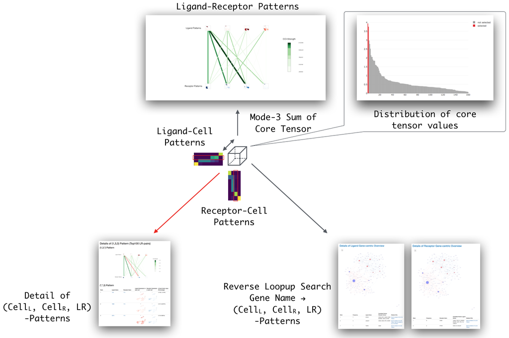

Figure2 : cellCellReport function of scTensor